# Final_work

李安昇

2/27/2017

## Read data

```r
raw_data <- read.csv("~/Dropbox/Course/Y2/R langeuage/final_work/train.csv")
```

## Look at the data frame

```r
str(raw_data)
```

```
## 'data.frame':    891 obs. of  12 variables:
##  $ PassengerId: int  1 2 3 4 5 6 7 8 9 10 ...
##  $ Survived   : int  0 1 1 1 0 0 0 0 1 1 ...
##  $ Pclass     : int  3 1 3 1 3 3 1 3 3 2 ...
##  $ Name       : Factor w/ 891 levels "Abbing, Mr. Anthony",..: 109 191 358 277 16 559 520 629 417 581 ...
##  $ Sex        : Factor w/ 2 levels "female","male": 2 1 1 1 2 2 2 2 1 1 ...
##  $ Age        : num  22 38 26 35 35 NA 54 2 27 14 ...
##  $ SibSp      : int  1 1 0 1 0 0 0 3 0 1 ...
##  $ Parch      : int  0 0 0 0 0 0 0 1 2 0 ...
##  $ Ticket     : Factor w/ 681 levels "110152","110413",..: 524 597 670 50 473 276 86 396 345 133 ...
##  $ Fare       : num  7.25 71.28 7.92 53.1 8.05 ...
##  $ Cabin      : Factor w/ 148 levels "","A10","A14",..: 1 83 1 57 1 1 131 1 1 1 ...
##  $ Embarked   : Factor w/ 4 levels "","C","Q","S": 4 2 4 4 4 3 4 4 4 2 ...
```

## Make descriptive statistic analysis of the data

realize there are 177 NA’s in Age, 2 null in Embarked and 687 null in Cabin

```r
summary(raw_data)
```

```
##   PassengerId       Survived          Pclass
##  Min.   :  1.0   Min.   :0.0000   Min.   :1.000
##  1st Qu.:223.5   1st Qu.:0.0000   1st Qu.:2.000
##  Median :446.0   Median :0.0000   Median :3.000
##  Mean   :446.0   Mean   :0.3838   Mean   :2.309
##  3rd Qu.:668.5   3rd Qu.:1.0000   3rd Qu.:3.000
##  Max.   :891.0   Max.   :1.0000   Max.   :3.000
##
##                                     Name         Sex           Age
##  Abbing, Mr. Anthony                  :  1   female:314   Min.   : 0.42
##  Abbott, Mr. Rossmore Edward          :  1   male  :577   1st Qu.:20.12
##  Abbott, Mrs. Stanton (Rosa Hunt)     :  1                Median :28.00
##  Abelson, Mr. Samuel                  :  1                Mean   :29.70
##  Abelson, Mrs. Samuel (Hannah Wizosky):  1                3rd Qu.:38.00
##  Adahl, Mr. Mauritz Nils Martin       :  1                Max.   :80.00
##  (Other)                              :885                NA's   :177
##      SibSp           Parch             Ticket         Fare
##  Min.   :0.000   Min.   :0.0000   1601    :  7   Min.   :  0.00
##  1st Qu.:0.000   1st Qu.:0.0000   347082  :  7   1st Qu.:  7.91
##  Median :0.000   Median :0.0000   CA. 2343:  7   Median : 14.45
##  Mean   :0.523   Mean   :0.3816   3101295 :  6   Mean   : 32.20
##  3rd Qu.:1.000   3rd Qu.:0.0000   347088  :  6   3rd Qu.: 31.00
##  Max.   :8.000   Max.   :6.0000   CA 2144 :  6   Max.   :512.33
##                                   (Other) :852
##          Cabin     Embarked
##             :687    :  2
##  B96 B98    :  4   C:168
##  C23 C25 C27:  4   Q: 77
##  G6         :  4   S:644
##  C22 C26    :  3
##  D          :  3
##  (Other)    :186
```

## Fill the NA’s in Age

```r
library(randomForest)
library(dplyr)
```

separate the train & test data

```r
with_age <- subset(raw_data, Age != "NA")
set.seed(66)
train_age <- sample_frac(with_age, size = 0.7 )   # use sample_frac() to sellect 70% of the data randomly
test_age <- setdiff(with_age, train_age)      # use sediff() to sellect the observations not being selected by train_age
```

construct model

```r
forest_fit_age <- randomForest(Age ~ Survived + Pclass + Sex + SibSp + Parch + Fare , data = train_age, ntree = 100)
```

use the modle to predict test

```r
prediction <- predict(forest_fit_age, newdata = test_age[, c( "Survived","Pclass", "Sex", "SibSp", "Parch", "Fare" )], type = "class")
#prediction <- predict(forest_fit_age, newdata = test_age[, c( "Survived","Pclass", "Sex", "SibSp", "Parch", "Fare" )], type = "response")
# these two types end up same result
```

calculate prediction error (root mean square error)

```r
rmse_age <- (prediction - test_age$Age)^2 %>%
  mean() %>%
  sqrt() %>%
  round(2)
rmse_age
```

```
## [1] 12.08
```

```r
# it's accepatable
```

replace the NA’s with prediction in age

```r
without_age <- setdiff(raw_data, with_age)
Age <- predict(forest_fit_age, newdata = without_age[ , c( "Survived","Pclass", "Sex", "SibSp", "Parch", "Fare" )], type = "class")
tmp <- without_age
tmp$Age <- NULL
full_data <- cbind(tmp, Age) %>%
  merge(with_age,all.x = TRUE, all.y = TRUE)
```

## Fill the null in Embarked with S

```r
full_data$Embarked <- as.character(full_data$Embarked)
full_data$Embarked[full_data$Embarked == ""] <- "S"
full_data$Embarked <- factor(full_data$Embarked)
```

## Exporatory statistical analysis: principal components analysis

```r
data_for_pca <- select(full_data, Pclass, Sex, SibSp, Parch, Fare,  Age)
data_for_pca$Sex <- as.numeric(data_for_pca$Sex)
titanic.pca <- prcomp(data_for_pca, center = TRUE, scale. = TRUE)
print(titanic.pca)
```

```
## Standard deviations:
## [1] 1.3477971 1.3265081 0.9348102 0.8116242 0.7326393 0.5953612
##
## Rotation:
##                PC1         PC2         PC3         PC4         PC5
## Pclass -0.03833689  0.67225441 -0.05666596 -0.13864347 -0.06816739
## Sex    -0.38060420  0.14305272  0.86853212  0.05291002 -0.25994375
## SibSp   0.54276528  0.14339509  0.42555481  0.01438576  0.70960375
## Parch   0.56889179  0.02243556  0.11763069 -0.62609221 -0.49784482
## Fare    0.32491950 -0.54266746  0.19709121  0.38260734 -0.26354445
## Age    -0.36036928 -0.46049587  0.09307040 -0.66286631  0.32701655
##                 PC6
## Pclass  0.720780447
## Sex    -0.099790244
## SibSp  -0.001538954
## Parch  -0.148932442
## Fare    0.587580076
## Age     0.321066766
```

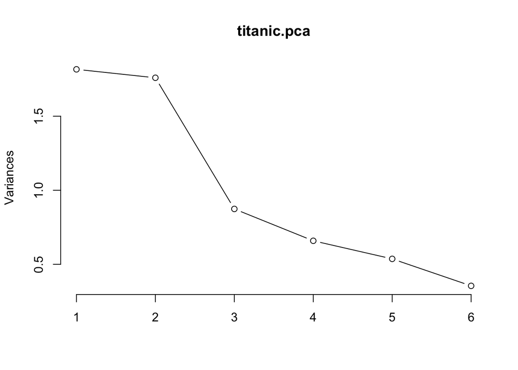

```r
# visualization https://www.r-bloggers.com/computing-and-visualizing-pca-in-r/

plot(titanic.pca, type = "l")
```

```r
summary(titanic.pca)
```

```
## Importance of components:
##                           PC1    PC2    PC3    PC4     PC5     PC6
## Standard deviation     1.3478 1.3265 0.9348 0.8116 0.73264 0.59536
## Proportion of Variance 0.3028 0.2933 0.1457 0.1098 0.08946 0.05908
## Cumulative Proportion  0.3028 0.5960 0.7417 0.8515 0.94092 1.00000
```

```r
# take 3 PCs
```

```r
#install.packages("devtools")
library(devtools)
# install_github("ggbiplot", "vqv")  # packages to help drawing PCA results quickly
# https://www.rdocumentation.org/packages/ggbiplot/versions/0.55/topics/ggbiplot
library(plyr); library(dplyr)
library(ggbiplot)
```

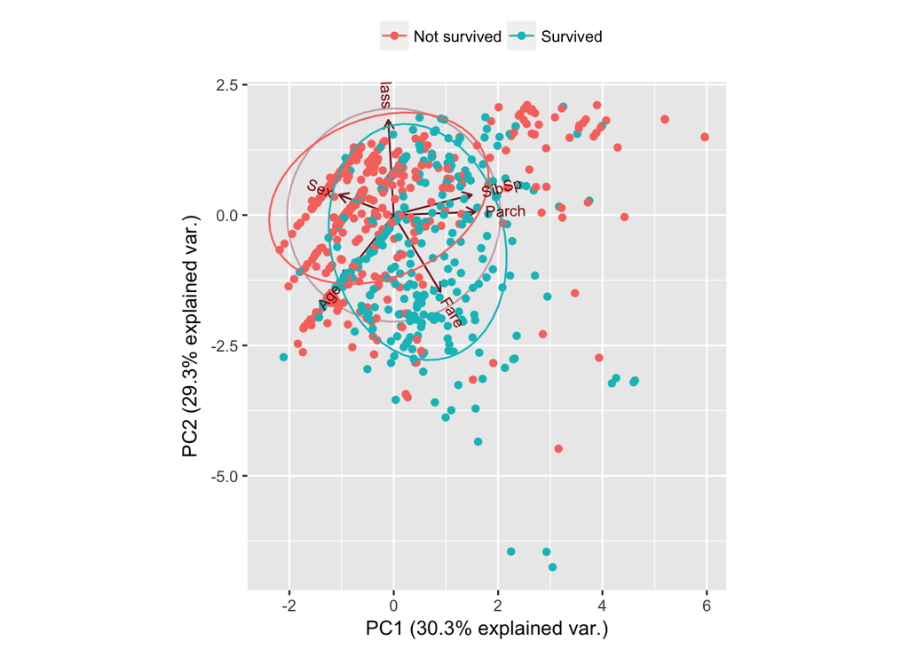

```r
titanic_sur <- 1 : nrow(full_data)
for(i in 1 : nrow(full_data)){
  if(full_data$Survived[i] == 1){
    titanic_sur[i] <- "Survived"
  } else {
    titanic_sur[i] <- "Not survived"
  }
}

# par(mfrow = c(1,2)) # ggbiplot doesn't follow this command
g1 <- ggbiplot(titanic.pca , obs.scale = 1, var.scale = 1,
              groups = titanic_sur, ellipse = TRUE,
              circle = TRUE, choices = 1:2) +
  scale_color_discrete(name = '') +
  theme(legend.direction = 'horizontal',
               legend.position = 'top')
print(g1)
```

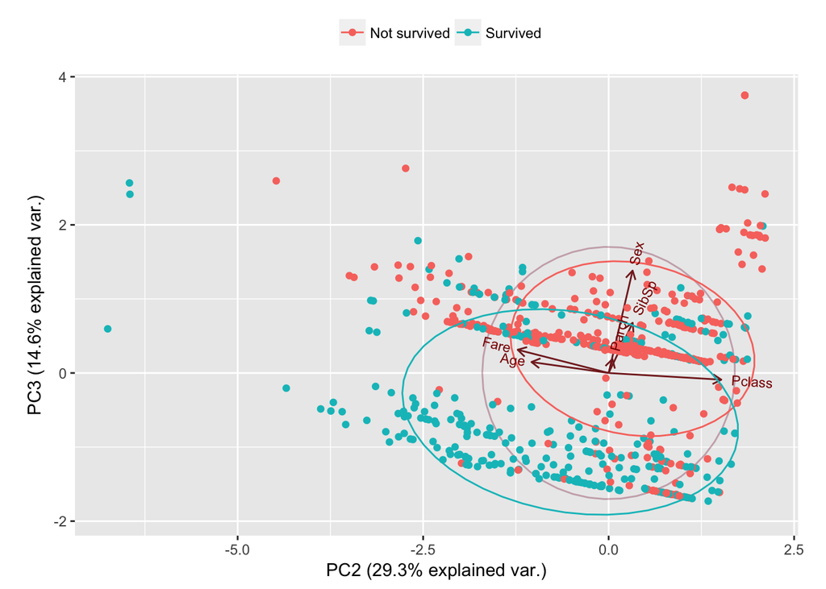

```r
g2 <- ggbiplot(titanic.pca , obs.scale = 1, var.scale = 1,
               groups = titanic_sur, ellipse = TRUE,
               circle = TRUE, choices = 2:3) +
  scale_color_discrete(name = '') +
  theme(legend.direction = 'horizontal',
        legend.position = 'top')
print(g2)
```

## Build survival model

```r
library(randomForest)
```

```r
set.seed(666)
train_sur <- sample_frac(full_data, size = 0.7)
test_sur <- setdiff(full_data, train_sur)
train_sur$Survived <- as.factor(train_sur$Survived)   # needed for classification
forest_fit_sur <- randomForest( Survived ~ Pclass + Sex + Age + SibSp + Parch + Fare + Embarked, data = train_sur, ntree = 100 )
```

# use the modle to predict test

```r
prediction_sur <- predict(forest_fit_sur, test_sur[, c("Pclass", "Sex", "Age", "SibSp", "Parch", "Fare", "Embarked")], type = "class")
```

calculate accuracy

```r
confusion_matrix <- table(test_sur$Survived, prediction_sur)
accuracy <- sum(diag(confusion_matrix)) / sum(confusion_matrix)
accuracy
```

```
## [1] 0.8576779
```

## Pridict test.csv data

find 86 NA’s in Age and 1 NA’s in Fare

```r
to_predict <- read.csv("~/Dropbox/Course/Y2/R langeuage/final_work/test.csv")
```

fill Age NA’s

```r
fit_age_no_sur <- randomForest(Age ~ Pclass + Sex + SibSp + Parch + Fare , data = train_age, ntree = 100)

tmp <- to_predict[is.na(to_predict$Age), ]
t_with_age <- tmp[ ,c("Pclass", "Sex", "Age", "SibSp", "Parch", "Fare", "Embarked")] %>%
  predict(fit_age_no_sur, . , type = "class" )

tmp$Age <- t_with_age
filter_to_predict <- subset(to_predict, Age != "NA")
to_predict <- merge(filter_to_predict, tmp, all.x = TRUE,  all.y = TRUE)
```

fill Fare NA’s data

```r
fare_mean <- mean(to_predict$Fare, na.rm = TRUE)
to_predict$Fare[is.na(to_predict$Fare)] <- fare_mean
summary(to_predict)
```

```
##   PassengerId         Pclass
##  Min.   : 892.0   Min.   :1.000
##  1st Qu.: 996.2   1st Qu.:1.000
##  Median :1100.5   Median :3.000
##  Mean   :1100.5   Mean   :2.266
##  3rd Qu.:1204.8   3rd Qu.:3.000
##  Max.   :1309.0   Max.   :3.000
##
##                                         Name         Sex
##  Abbott, Master. Eugene Joseph            :  1   female:152
##  Abelseth, Miss. Karen Marie              :  1   male  :266
##  Abelseth, Mr. Olaus Jorgensen            :  1
##  Abrahamsson, Mr. Abraham August Johannes :  1
##  Abrahim, Mrs. Joseph (Sophie Halaut Easu):  1
##  Aks, Master. Philip Frank                :  1
##  (Other)                                  :412
##       Age            SibSp            Parch             Ticket
##  Min.   : 0.17   Min.   :0.0000   Min.   :0.0000   PC 17608:  5
##  1st Qu.:22.51   1st Qu.:0.0000   1st Qu.:0.0000   113503  :  4
##  Median :29.00   Median :0.0000   Median :0.0000   CA. 2343:  4
##  Mean   :30.17   Mean   :0.4474   Mean   :0.3923   16966   :  3
##  3rd Qu.:36.00   3rd Qu.:1.0000   3rd Qu.:0.0000   220845  :  3
##  Max.   :76.00   Max.   :8.0000   Max.   :9.0000   347077  :  3
##                                                    (Other) :396
##       Fare                     Cabin     Embarked
##  Min.   :  0.000                  :327   C:102
##  1st Qu.:  7.896   B57 B59 B63 B66:  3   Q: 46
##  Median : 14.454   A34            :  2   S:270
##  Mean   : 35.627   B45            :  2
##  3rd Qu.: 31.500   C101           :  2
##  Max.   :512.329   C116           :  2
##                    (Other)        : 80
```

# Predict survivals

This part works successfully in script, but I really don’t know why it is wrong in R Markdown…. Therefore I copy the codes as texts insdead of recognizeing them as R script.

*predicted <- predict(forest_fit_sur, newdata = to_predict[ ,c(“Pclass”, “Sex”, “Age”, “SibSp”, “Parch”, “Fare”, “Embarked”)], type = “class”)*

*to_submit <- data.frame(to_predict[ ,“PassengerId”], predicted)*

*names(to_submit) <- c(“PassengerId”, “Survived”)*

*head(to_submit, n = 10)*

*write.csv(to_submit, file = “~/Dropbox/Course/Y2/R langeuage/final_work/to_submit.csv”, row.names = FALSE)*

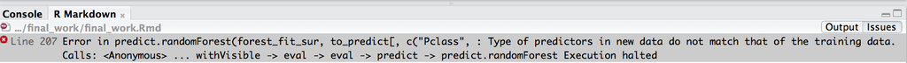

This the error message from R Markdown

## This is the to_submit file successfully generaded by the script above.

```r
to_submit <- read.csv("~/Dropbox/Course/Y2/R langeuage/final_work/to_submit.csv")
head(to_submit, 10)
```

```
##    PassengerId Survived
## 1          892        0
## 2          893        0
## 3          894        0
## 4          895        0
## 5          896        0
## 6          897        0
## 7          898        0
## 8          899        0
## 9          900        1
## 10         901        0
```

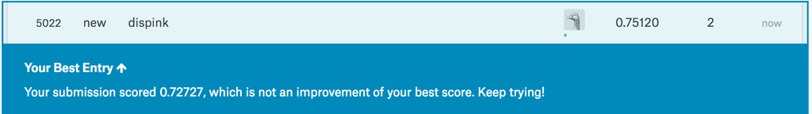

Kaggle Submission